# Campus Placement Dataset Analysis

## Salary vs Academic results

##### Does the grade in school affect your future life?

##### Lower Secondary Eduacation vs Salary

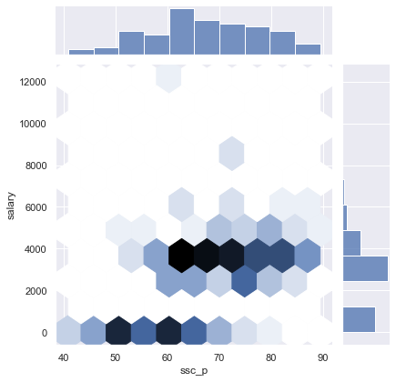

```python
sns.jointplot(x = dataset['ssc_p'], y = dataset['salary'], kind='hex')
```

##### Higher Secondary Education vs Salary

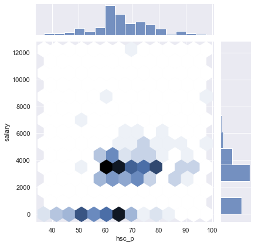

```python
sns.jointplot(x = dataset['hsc_p'], y = dataset['salary'], kind='hex')
```

##### Undergraduate vs Salary

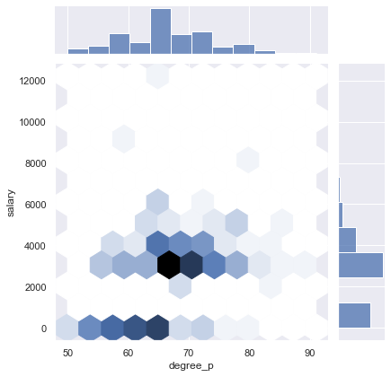

```python
sns.jointplot(x = dataset['degree_p'], y = dataset['salary'], kind='hex')
```

##### Post Graduation vs Salary

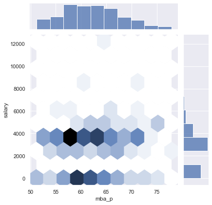

```python
sns.jointplot(x = dataset['mba_p'], y = dataset['salary'], kind='hex')
```

### Which stream students are getting more placed and which stream students are mostly not placed?

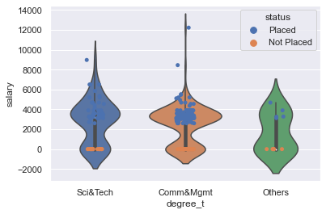

```python
sns.violinplot(x=dataset["degree_t"], y=dataset["salary"], data=dataset)
sns.stripplot(x=dataset["degree_t"], y=dataset["salary"], data=dataset,hue=dataset['status'])
plt.show()
```

### Does Percentage in College determine salary ?

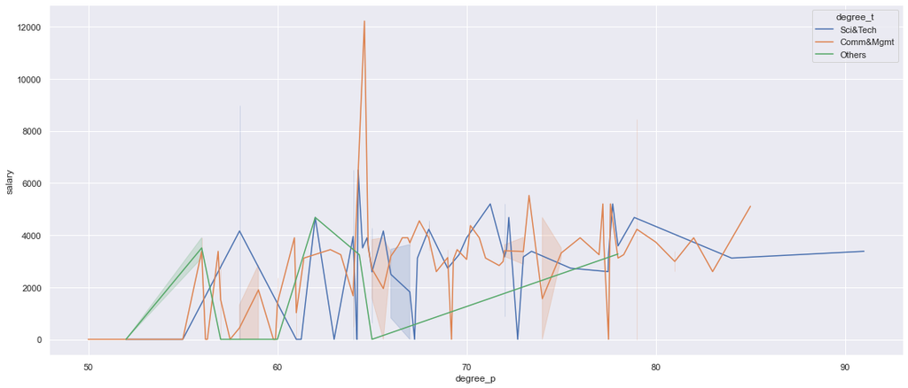

```python
plt.figure(figsize =(19,8))
sns.lineplot(dataset["degree_p"], dataset["salary"], hue=dataset["degree_t"], data=dataset)

plt.show()
```

- Percentage does not seem to affect salary.
- Commerce&Mgmt students occasionally get dream placements with high salary

### Relation between EmployabilityTest and PlacementStatus

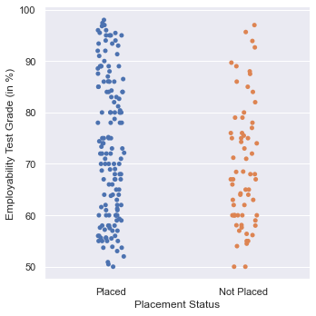

```python
plot = sns.catplot(x="PlacementStatus", y="EmployabilityTestGrade%", data=data)
plt.xlabel("Placement Status")
plt.ylabel("Employability Test Grade (in %)")
plot.savefig("images/EmployabilityTest.png")
```

Surprisingly, the employability test seems to not be a major factor to the placement rate. There are a lot of students with good scores that did not land a job. It may be necessary for the institution to rethink this test.

#### Salary Vs Employability Test

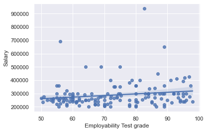

```python
sns.regplot(x="EmployabilityTestGrade%", y="Salary", data=data)
plt.xlabel("Employability Test grade")
```

There is a positive relation between salary and the employability test. It is not huge, but it is visible.

### Is the MBAGrade important?

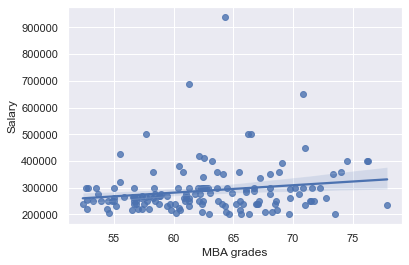

```python
sns.regplot(x="MBAGrade%", y="Salary", data=data)
plt.xlabel("MBA grades")
```

### How about work experience?

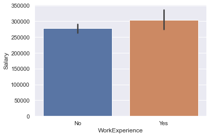

```python
sns.barplot(x="WorkExperience", y="Salary", data=data)
```

```python
salary_with_experience = np.mean(data[data["WorkExperience"] == "Yes"]["Salary"])
salary_no_experience = np.mean(data[data["WorkExperience"] == "No"]["Salary"])
print("Salary with work experience: ", salary_with_experience)
print("Salary with no work experience: ", salary_no_experience)
print("Percentual difference: ", 100*(salary_with_experience / salary_no_experience - 1))
```

```
Salary with work experience:  303265.625
Salary with no work experience:  277523.8095238095
Percentual difference:  9.275534059711731
```

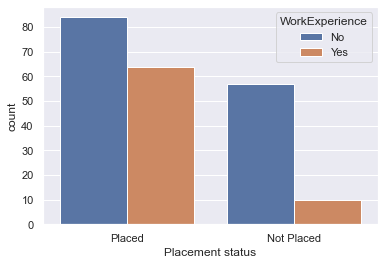

```python
sns.countplot(x="PlacementStatus", hue="WorkExperience", data=data)
plt.xlabel("Placement status")
```

```python
placement_with_experience = data[data["WorkExperience"] == "Yes"]["PlacementStatus"] == "Placed"
placement_no_experience = data[data["WorkExperience"] == "No"]["PlacementStatus"] == "Placed"

print("Placement with work experience: ", placement_with_experience.mean())
print("Placement with no work experience: ", placement_no_experience.mean())
print("Percentual difference: ", 100*(placement_with_experience.mean() / placement_no_experience.mean() - 1))

# print("Salary with work experience: ", salary_with_experience)
# print("Salary with no work experience: ", salary_no_experience)
# print("Percentual difference: ", 100*(salary_with_experience / salary_no_experience - 1))
```

```
Placement with work experience:  0.8648648648648649
Placement with no work experience:  0.5957446808510638
Percentual difference:  45.173745173745196
```

## Encoding

We will Label Encode (no new columns) categorical features that only have two unique values. e.g. Gender M/F and Hot Encoded every other categorical column (columns with more than 2 unique values)

```python
def label_encoding(data):
    le = LabelEncoder()
    le.fit(data)
    return le.transform(data)
```

```python
def one_hot_encoding(data):
    return pd.get_dummies(data)
```

```python
data["Gender"] = label_encoding(data["Gender"])
data["LowerSecondarySchollBoard"] = label_encoding(data["LowerSecondarySchollBoard"])
data["HigherSecondarySchollBoard"] = label_encoding(data["HigherSecondarySchollBoard"])
data["WorkExperience"] = label_encoding(data["WorkExperience"])
data["MBASpecialization"] = label_encoding(data["MBASpecialization"])
data["PlacementStatus"] = label_encoding(data["PlacementStatus"])
```

```python
data = one_hot_encoding(data)
```

```python
data.head(5)
```

|  | Gender | LowerSecondarySchollGrade% | LowerSecondarySchollBoard | HigherSecondarySchollGrade% | HigherSecondarySchollBoard | DegreeGrade% | WorkExperience | EmployabilityTestGrade% | MBASpecialization | MBAGrade% | PlacementStatus | Salary | HigherSecondarySchollSpecialization_Arts | HigherSecondarySchollSpecialization_Commerce | HigherSecondarySchollSpecialization_Science | DegreeSpecialization_Comm&Mgmt | DegreeSpecialization_Others | DegreeSpecialization_Sci&Tech |
| --- | --- | --- | --- | --- | --- | --- | --- | --- | --- | --- | --- | --- | --- | --- | --- | --- | --- | --- |
| 0 | 1 | 67.00 | 1 | 91.00 | 1 | 58.00 | 0 | 55.0 | 1 | 58.80 | 1 | 270000.0 | 0 | 1 | 0 | 0 | 0 | 1 |
| 1 | 1 | 79.33 | 0 | 78.33 | 1 | 77.48 | 1 | 86.5 | 0 | 66.28 | 1 | 200000.0 | 0 | 0 | 1 | 0 | 0 | 1 |
| 2 | 1 | 65.00 | 0 | 68.00 | 0 | 64.00 | 0 | 75.0 | 0 | 57.80 | 1 | 250000.0 | 1 | 0 | 0 | 1 | 0 | 0 |
| 3 | 1 | 56.00 | 0 | 52.00 | 0 | 52.00 | 0 | 66.0 | 1 | 59.43 | 0 | NaN | 0 | 0 | 1 | 0 | 0 | 1 |
| 4 | 1 | 85.80 | 0 | 73.60 | 0 | 73.30 | 0 | 96.8 | 0 | 55.50 | 1 | 425000.0 | 0 | 1 | 0 | 1 | 0 | 0 |

## Correlations

```python
salary_corr = data[data["PlacementStatus"] == 1].corr()["Salary"].sort_values()

# Display correlations
salary_corr # corr() returns NaN if all values are that same, which is the case with PlacementStatus
```

```
DegreeSpecialization_Comm&Mgmt                 -0.160322
MBASpecialization                              -0.146576
HigherSecondarySchollSpecialization_Arts       -0.088253
DegreeGrade%                                   -0.019272
DegreeSpecialization_Others                    -0.016573
HigherSecondarySchollSpecialization_Commerce   -0.014219
HigherSecondarySchollBoard                     -0.007549
LowerSecondarySchollBoard                       0.005539
LowerSecondarySchollGrade%                      0.035330
HigherSecondarySchollSpecialization_Science     0.049547
HigherSecondarySchollGrade%                     0.076819
WorkExperience                                  0.136920
Gender                                          0.158912
DegreeSpecialization_Sci&Tech                   0.172492
MBAGrade%                                       0.175013
EmployabilityTestGrade%                         0.178307
Salary                                          1.000000
PlacementStatus                                      NaN
Name: Salary, dtype: float64
```

### Heat Map for checking correlation

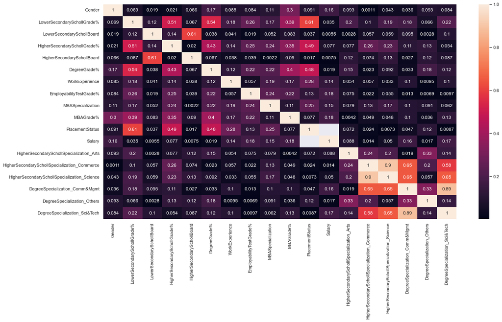

```python
plt.figure(figsize=(20,10))
sns.heatmap(data.corr().abs(), annot=True)
```

Here we are looking at PlacementStatus, so Salary is not important and we will ignore the NaN

```python
placement_corr = data.corr()["PlacementStatus"].sort_values()

# Display correlations
placement_corr # placement_corr = data.corr()["PlacementStatus"].sort_values()

# Display correlations
placement_corr
```

```
MBASpecialization                              -0.250655
DegreeSpecialization_Others                    -0.117232
HigherSecondarySchollSpecialization_Arts       -0.071653
HigherSecondarySchollSpecialization_Science     0.007279
DegreeSpecialization_Sci&Tech                   0.008688
HigherSecondarySchollBoard                      0.016945
HigherSecondarySchollSpecialization_Commerce    0.024414
LowerSecondarySchollBoard                       0.037297
DegreeSpecialization_Comm&Mgmt                  0.046849
MBAGrade%                                       0.076922
Gender                                          0.090670
EmployabilityTestGrade%                         0.127639
WorkExperience                                  0.276060
DegreeGrade%                                    0.479861
HigherSecondarySchollGrade%                     0.491228
LowerSecondarySchollGrade%                      0.607889
PlacementStatus                                 1.000000
Salary                                               NaN
Name: PlacementStatus, dtype: float64
```

Here we are looking at PlacementStatus, so Salary is not important and we will ignore the NaN

### Observations

These results allow us to see what are the features that most relate with what we are trying to predict. In the case o PlacementStatus, having high grades during your education (specially basic education) has a huge factor on employability, alongside work experience and the MBA field of choice. In the case of salary, major factors are the specialization and most recent grades.

## Questions

### What are the major factors that lead to the person being hired

We already answered this question in the data analysis phase. Things like MBA area of specialization, experience and grades are the most important here.

We will try to predict if someone who just graduated from the MBA is employed.

First, the preprocessing: remove the salary and any other feature that does not seems to be related to the problem. Finally, standardize the data.

```python
placement_corr = data.corr()["PlacementStatus"].sort_values()

# Display correlations
 # Here we are looking at PlacementStatus, so Salary is not important and we will ignore the NaN
```

```python
columns_to_drop = [
    "Salary",
    "HigherSecondarySchollSpecialization_Arts",
    "HigherSecondarySchollSpecialization_Science",
    "HigherSecondarySchollSpecialization_Commerce",
    "DegreeSpecialization_Sci&Tech",
    "DegreeSpecialization_Comm&Mgmt",
    "DegreeSpecialization_Others",
    "MBAGrade%"
]
placement_data = data.drop(columns_to_drop, axis=1)
```

```python
y = placement_data["PlacementStatus"]
X = placement_data.drop(["PlacementStatus"], axis=1)

X_train, X_test, y_train, y_test = train_test_split(X, y, test_size=0.1, random_state=42)
```

```python
X_train = (X_train - X_train.mean()) / X_train.std()
X_test = (X_test - X_test.mean()) / X_test.std()
```

```python
X_train.head(5)
```

|  | Gender | LowerSecondarySchollGrade% | LowerSecondarySchollBoard | HigherSecondarySchollGrade% | HigherSecondarySchollBoard | DegreeGrade% | WorkExperience | EmployabilityTestGrade% | MBASpecialization |
| --- | --- | --- | --- | --- | --- | --- | --- | --- | --- |
| 79 | -1.367791 | 0.162888 | -0.913101 | -0.379024 | -1.237537 | -0.043779 | -0.710761 | 0.192690 | 1.100944 |
| 25 | -1.367791 | -1.372102 | 1.089495 | -1.042572 | -1.237537 | -2.148106 | 1.399653 | 0.268148 | -0.903605 |
| 104 | 0.727318 | 0.162888 | -0.913101 | -0.289355 | 0.803870 | -0.176964 | 1.399653 | -1.316460 | 1.100944 |
| 145 | 0.727318 | 2.069940 | 1.089495 | -0.050837 | 0.803870 | 0.655444 | -0.710761 | -0.033682 | 1.100944 |
| 189 | -1.367791 | -1.239356 | -0.913101 | 1.019806 | 0.803870 | 0.382414 | -0.710761 | 1.750888 | -0.903605 |

```python
X_test.head(5)
```

|  | Gender | LowerSecondarySchollGrade% | LowerSecondarySchollBoard | HigherSecondarySchollGrade% | HigherSecondarySchollBoard | DegreeGrade% | WorkExperience | EmployabilityTestGrade% | MBASpecialization |
| --- | --- | --- | --- | --- | --- | --- | --- | --- | --- |
| 200 | 0.812920 | 0.106333 | 0.977008 | -0.855848 | 0.738549 | -0.288051 | -0.812920 | 1.379209 | -0.738549 |
| 212 | 0.812920 | -0.057945 | 0.977008 | -0.031218 | 0.738549 | 1.040835 | 1.174218 | -0.751182 | -0.738549 |
| 138 | -1.174218 | 1.174140 | 0.977008 | -0.384631 | 0.738549 | 1.040835 | 1.174218 | 2.009745 | -0.738549 |
| 176 | -1.174218 | -0.715058 | -0.977008 | -0.855848 | 0.738549 | -1.783049 | -0.812920 | -1.049661 | 1.292461 |
| 15 | -1.174218 | -0.222223 | -0.977008 | 0.911216 | -1.292461 | 0.376392 | 1.174218 | 0.218873 | -0.738549 |

### What are the major factors that affect the salary?

As we saw in the data analysis phase, the most important features in this problem are MBA and the Employability Test grades, the degree and MBA areas of specialization, gender and work experience. we will build a model that predicts the salary of someone who just graduated from the MBA (assuming this person got hired).

```python
salary_corr = data[data["PlacementStatus"] == 1].corr()["Salary"].sort_values()

# Display correlations
salary_corr
```

```
DegreeSpecialization_Comm&Mgmt                 -0.160322
MBASpecialization                              -0.146576
HigherSecondarySchollSpecialization_Arts       -0.088253
DegreeGrade%                                   -0.019272
DegreeSpecialization_Others                    -0.016573
HigherSecondarySchollSpecialization_Commerce   -0.014219
HigherSecondarySchollBoard                     -0.007549
LowerSecondarySchollBoard                       0.005539
LowerSecondarySchollGrade%                      0.035330
HigherSecondarySchollSpecialization_Science     0.049547
HigherSecondarySchollGrade%                     0.076819
WorkExperience                                  0.136920
Gender                                          0.158912
DegreeSpecialization_Sci&Tech                   0.172492
MBAGrade%                                       0.175013
EmployabilityTestGrade%                         0.178307
Salary                                          1.000000
PlacementStatus                                      NaN
Name: Salary, dtype: float64
```

Correlation returns NaN if all values are that same, which is the case with PlacementStatus

```python
columns_to_keep = [
    "Salary",
    "EmployabilityTestGrade%",
    "MBAGrade%",
    "DegreeSpecialization_Sci&Tech",
    "DegreeSpecialization_Comm&Mgmt",
    "Gender",
    "WorkExperience",
    "MBASpecialization"
]
salary_data = data[columns_to_keep]
```

```python
salary_data = salary_data[salary_data['Salary'].notna()]
```

```python
y = salary_data["Salary"]
X = salary_data.drop(["Salary"], axis=1)

X_train, X_test, y_train, y_test = train_test_split(X, y, test_size=0.1, random_state=42)
```

```python
X_train = (X_train - X_train.mean()) / X_train.std()
X_test = (X_test - X_test.mean()) / X_test.std()
```

```python
X_train.head(10)
```

|  | EmployabilityTestGrade% | MBAGrade% | DegreeSpecialization_Sci&Tech | DegreeSpecialization_Comm&Mgmt | Gender | WorkExperience | MBASpecialization |
| --- | --- | --- | --- | --- | --- | --- | --- |
| 95 | 1.605444 | -0.038434 | -0.606913 | 0.665057 | 0.700475 | 1.098872 | -0.736480 |
| 27 | -0.380194 | -0.790559 | -0.606913 | 0.665057 | 0.700475 | -0.903182 | 1.347601 |
| 101 | 0.342908 | -0.327842 | -0.606913 | 0.665057 | 0.700475 | -0.903182 | 1.347601 |
| 177 | 1.138320 | 1.417020 | -0.606913 | 0.665057 | -1.416869 | 1.098872 | -0.736480 |
| 47 | 0.342908 | -1.318897 | -0.606913 | 0.665057 | 0.700475 | 1.098872 | -0.736480 |
| 44 | 1.138320 | 1.230250 | -0.606913 | 0.665057 | -1.416869 | 1.098872 | -0.736480 |
| 146 | 0.849079 | -1.219623 | -0.606913 | 0.665057 | 0.700475 | -0.903182 | 1.347601 |
| 56 | -0.380194 | 0.755756 | -0.606913 | 0.665057 | 0.700475 | -0.903182 | -0.736480 |
| 164 | -1.461954 | 0.526921 | -0.606913 | 0.665057 | -1.416869 | -0.903182 | -0.736480 |
| 80 | -0.452504 | -0.006465 | -0.606913 | 0.665057 | -1.416869 | 1.098872 | 1.347601 |

```python
y_train.head(10)
```

```
95     420000.0
27     265000.0
101    380000.0
177    650000.0
47     204000.0
44     200000.0
146    233000.0
56     240000.0
164    250000.0
80     240000.0
Name: Salary, dtype: float64
```

```python
def trainRegression(X, Y):
    for degree in range(1, 4):
        name = 'Linear Regression degree' + str(degree)

        polynomial_features = PolynomialFeatures(degree=degree)
        X_poly = polynomial_features.fit_transform(X)

        model = LinearRegression()

        cv_results = cross_val_score(model, X_poly, Y, cv=10, scoring='r2')
        print('%s: %.6f (%.6f)' % (name, cv_results.mean(), cv_results.std()))
```

###### Linear Regression

```python
trainRegression(X_train, y_train)
```

```
Linear Regression degree1: -0.300547 (0.593319)
Linear Regression degree2: -56012702404937373576069120.000000 (167397531279467017331015680.000000)
Linear Regression degree3: -1273200841177254913376256.000000 (2553128309561786567229440.000000)
```

These results show that it is better to just use Linear Regression instead of polynomial regression

```python
model = LinearRegression()
model.fit(X_train, y_train)
print(model.predict(X_test))
print(y_test.values)
print(r2_score(y_test, model.predict(X_test)))
```

```
[303555.88575642 302070.63156475 253695.20532424 306526.57108331
 291716.43907118 241686.34186756 239362.40691229 280510.03222008
 322901.97097687 279396.03079504 319113.87953033 296539.86383578
 322601.86041505 275781.6899594  272699.08542453]
[350000. 336000. 260000. 350000. 400000. 265000. 250000. 250000. 240000.
 200000. 411000. 250000. 400000. 300000. 260000.]
0.23452225966615792
```

#### Observation

Results are not great, but the amount of data does not help very much

### Can the institution predict if the person will be successfull before they are accepted?

```python
columns_to_keep = {
    "Gender",
    "LowerSecondarySchollGrade%",
    "HigherSecondarySchollGrade%",
    "DegreeGrade%",
    "WorkExperience",
    "MBASpecialization", # This one is about the MBA but the institution would already know it beforehand
    "HigherSecondarySchollSpecialization_Arts",
    "HigherSecondarySchollSpecialization_Commerce",
    "HigherSecondarySchollSpecialization_Science",
    "DegreeSpecialization_Comm&Mgmt",
    "DegreeSpecialization_Others",
    "DegreeSpecialization_Sci&Tech",
    "PlacementStatus"
}

before_mba_data = data[columns_to_keep]
```

The knowlodge from the data analysis phase can tell us what are the best features.

> "Things like MBA area of specialization, experience and grades are the most important here."

```python
placement_corr = before_mba_data.corr()["PlacementStatus"].sort_values()

# Display correlations
placement_corr # Here we are looking at PlacementStatus, so Salary is not important and we will ignore the NaN
```

```
MBASpecialization                              -0.250655
DegreeSpecialization_Others                    -0.117232
HigherSecondarySchollSpecialization_Arts       -0.071653
HigherSecondarySchollSpecialization_Science     0.007279
DegreeSpecialization_Sci&Tech                   0.008688
HigherSecondarySchollSpecialization_Commerce    0.024414
DegreeSpecialization_Comm&Mgmt                  0.046849
Gender                                          0.090670
WorkExperience                                  0.276060
DegreeGrade%                                    0.479861
HigherSecondarySchollGrade%                     0.491228
LowerSecondarySchollGrade%                      0.607889
PlacementStatus                                 1.000000
Name: PlacementStatus, dtype: float64
```

Here we are looking at PlacementStatus, so Salary is not important and we will ignore the NaN

```python
columns_to_keep = {
    "Gender",
    "LowerSecondarySchollGrade%",
    "HigherSecondarySchollGrade%",
    "DegreeGrade%",
    "WorkExperience",
    "MBASpecialization", # This one is about the MBA but the institution would already know it beforehand
#     "HigherSecondarySchollSpecialization_Arts",
#     "HigherSecondarySchollSpecialization_Commerce",
#     "HigherSecondarySchollSpecialization_Science",
#     "DegreeSpecialization_Comm&Mgmt",
#     "DegreeSpecialization_Others",
#     "DegreeSpecialization_Sci&Tech",
    "PlacementStatus"
}

before_mba_data = data[columns_to_keep]
```

```python
models = []
models.append(('LR', LogisticRegression(solver='liblinear', multi_class='ovr')))
models.append(('KNN', KNeighborsClassifier()))
models.append(('TREE', DecisionTreeClassifier()))
models.append(('SVM', SVC(gamma='auto', probability=True)))
models.append(('GB', GradientBoostingClassifier()))
models.append(('RF', RandomForestClassifier()))
```

```python
def runModels(X_train, Y_train, scoring='accuracy'):
    for name, model in models:
        kfold = StratifiedKFold(n_splits=5, random_state=42, shuffle=True)
        cv_results = cross_val_score(model, X_train, Y_train, cv=kfold, scoring=scoring)
        print('%s: %.6f (%.6f)' % (name, cv_results.mean(), cv_results.std()))
```

```python
runModels(X_train, y_train, scoring='f1')
```

[output not shown]

[output not shown]

[output cut: 248 more lines]

[output not shown]

```
LR: nan (nan)
KNN: nan (nan)
TREE: nan (nan)
```

[output not shown]

[output cut: 42 more lines]

[output not shown]

```
SVM: nan (nan)
```

```python
!jupyter nbconvert --to html Campus-placement-data-anal.ipynb
```

[output not shown]